# NHANES 2017–2020: Health Insurance and Blood-Sugar Screening

Doubly robust estimation (AIPW)

Sujit Silas Armstrong

June 11, 2026

# 1. Overview

**Estimand.** Average treatment effect (ATE) of health-insurance coverage ($A$: insured vs. uninsured) on blood-sugar screening ($Y$), on the **risk- difference** scale,
$$\tau =
\mathbb{E}\!\left[Y^{1}\right] -
\mathbb{E}\!\left[Y^{0}\right],$$
identified under the assumptions in `../nhanes_data_prep.Rmd` and the adjustment set in `../nhanes_dag.Rmd`.

$\hat\tau = \overline{\hat\mu_1} - \overline{\hat\mu_0}$ is **consistent if *either*** the propensity model **or** the outcome model is correctly specified (double robustness). We carry the NHANES survey weights through every step so the estimate targets the U.S. adult population, and we obtain design-based confidence intervals from the survey package.

# 2. Load, recode, complete-case

```r
df <- read.csv(data_path, stringsAsFactors = FALSE)

df <- df %>%
  mutate(
    screened_bin = ifelse(screened == "Screened", 1, 0),
    treat        = ifelse(insured == "Insured", 1, 0),   # 1 = insured (treated)

    insured  = factor(insured, levels = c("Uninsured", "Insured")),
    sex      = factor(sex, levels = c("Male", "Female")),
    race_eth = factor(race_eth, levels = c("Non-Hispanic White", "Mexican American",
                                           "Other Hispanic", "Non-Hispanic Black",
                                           "Non-Hispanic Asian", "Other/Multi")),
    education = factor(education, levels = c("< High school", "High school / GED",
                                             "Some college", "College graduate")),
    marital  = factor(marital, levels = c("Married / partnered",
                                          "Widowed / divorced / separated",
                                          "Never married")),
    us_born  = factor(us_born, levels = c("Born in U.S.", "Born outside U.S.")),
    interview_lang = factor(interview_lang, levels = c("English", "Spanish")),
    gen_health   = factor(gen_health, levels = c("Excellent", "Very good",
                                                 "Good", "Fair", "Poor")),
    hypertension = factor(hypertension, levels = c("No", "Yes")),
    smoked_100   = factor(smoked_100,   levels = c("No", "Yes")),
    alcohol_ever = factor(alcohol_ever, levels = c("No", "Yes"))
  ) %>%
  filter(WTMECPRP > 0)            # keep the MEC-examined sample (BMI measured there)

# adjustment set L (from the DAG). alcohol is dropped here to limit the
# complete-case loss it drives (~14% missing); revisit in sensitivity analysis.
covariates <- c("age", "sex", "race_eth", "education", "pir", "marital",
                "us_born", "interview_lang", "bmi", "gen_health",
                "hypertension", "smoked_100")

model_df <- df %>%
  tidyr::drop_na(all_of(c("treat", "screened_bin", covariates)))

cat("MEC-examined n:      ", nrow(df), "\n")
```

```
## MEC-examined n:       6894
```

```r
cat("complete-case n (L): ", nrow(model_df), "\n")
```

```
## complete-case n (L):  5822
```

```r
cat("  insured:   ", sum(model_df$treat == 1), "\n")
```

```
##   insured:    4854
```

```r
cat("  uninsured: ", sum(model_df$treat == 0), "\n")
```

```
##   uninsured:  968
```

# 3. Nuisance models

- We use `quasibinomial()` to avoid spurious non-integer-weight warnings; coefficients are identical to `binomial()`.

```r
# rescale survey weights to mean 1
model_df$sw <- model_df$WTMECPRP / mean(model_df$WTMECPRP)

# ---- propensity score: e(L) = P(insured = 1 | L) ----
ps_formula <- reformulate(covariates, response = "treat")
ps_fit <- glm(ps_formula, data = model_df,
              family = quasibinomial(), weights = sw)
model_df$ps <- predict(ps_fit, type = "response")

# ---- outcome models: m_a(L) = E(Y | A = a, L), fit separately by arm ----
y_formula <- reformulate(covariates, response = "screened_bin")
out1 <- glm(y_formula, data = filter(model_df, treat == 1),
            family = quasibinomial(), weights = sw)
out0 <- glm(y_formula, data = filter(model_df, treat == 0),
            family = quasibinomial(), weights = sw)

# counterfactual predictions for everyone under each arm
model_df$m1 <- predict(out1, newdata = model_df, type = "response")
model_df$m0 <- predict(out0, newdata = model_df, type = "response")
```

## 3.1 Positivity / overlap diagnostics

```r
cat("propensity range, uninsured:",
    round(range(model_df$ps[model_df$treat == 0]), 4), "\n")
```

```
## propensity range, uninsured: 0.1382 0.9923
```

```r
cat("propensity range, insured:  ",
    round(range(model_df$ps[model_df$treat == 1]), 4), "\n")
```

```
## propensity range, insured:   0.1751 0.9974
```

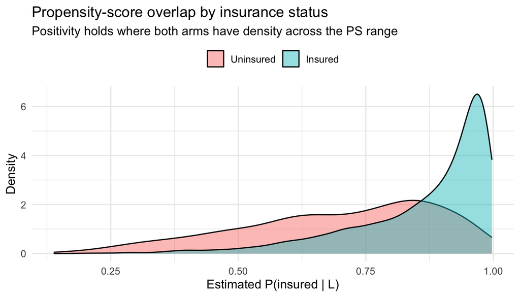

```r
ggplot(model_df, aes(ps, fill = insured)) +
  geom_density(alpha = 0.45) +
  labs(title = "Propensity-score overlap by insurance status",
       subtitle = "Positivity holds where both arms have density across the PS range",
       x = "Estimated P(insured | L)", y = "Density", fill = NULL) +
  theme(legend.position = "top")
```

```r
# IPT weights implied by the PS — inspect the tails for instability
model_df$ipt_w <- ifelse(model_df$treat == 1, 1 / model_df$ps, 1 / (1 - model_df$ps))
cat("\nIPT weight summary (unstabilized):\n"); print(summary(model_df$ipt_w))
```

```
##
## IPT weight summary (unstabilized):
```

```
##    Min. 1st Qu.  Median    Mean 3rd Qu.    Max.
##   1.003   1.042   1.135   2.133   1.478 129.693
```

## 3.2 Covariate balance (diagnostic)

Unlike IPW, AIPW’s validity does **not** hinge on balance — the outcome-model augmentation corrects whatever imbalance the weights leave behind. But because the IPW arm of the estimator uses these propensity weights, we confirm they pull the covariates toward balance; a standardized mean difference (SMD) below 0.1 is the usual target. Residual imbalance here is not fatal (it is exactly what the augmentation term mops up), but it flags which covariates the effect leans on the outcome model to adjust.

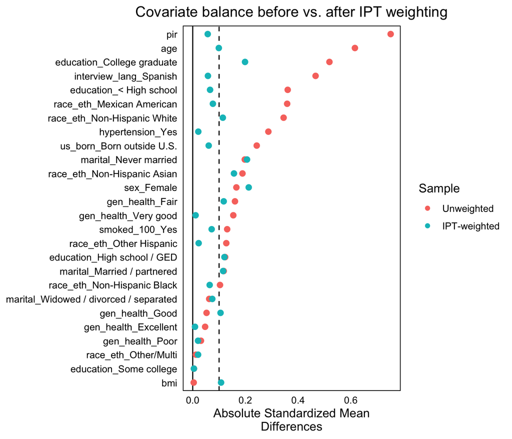

```r
bal_formula <- treat ~ age + sex + race_eth + education + pir + marital +
  us_born + interview_lang + bmi + gen_health + hypertension + smoked_100

cobalt::love.plot(
  bal_formula, data = model_df,
  weights = model_df$ipt_w,          # IPT weights from the AIPW propensity model
  binary = "std", abs = TRUE, threshold = 0.1,
  var.order = "unadjusted",
  sample.names = c("Unweighted", "IPT-weighted"),
  title = "Covariate balance before vs. after IPT weighting"
)
```

# 4. AIPW estimator

```r
model_df <- model_df %>%
  mutate(
    mu1 = m1 + treat       / ps       * (screened_bin - m1),   # pseudo-outcome for E[Y^1]
    mu0 = m0 + (1 - treat) / (1 - ps) * (screened_bin - m0),   # pseudo-outcome for E[Y^0]
    aipw_contrast = mu1 - mu0
  )

# design-based inference: the survey-weighted mean of the pseudo-outcomes IS the
# AIPW estimate of each potential-outcome mean; svycontrast gives the RD/RR/OR
# with delta-method CIs that respect the NHANES clustering and stratification.
aipw_design <- svydesign(id = ~SDMVPSU, strata = ~SDMVSTRA,
                         weights = ~WTMECPRP, data = model_df, nest = TRUE)

po  <- svymean(~mu1 + mu0, aipw_design)            # E[Y^1], E[Y^0]
rd  <- svycontrast(po, quote(mu1 - mu0))                           # risk difference
rr  <- svycontrast(po, quote(mu1 / mu0))                           # risk ratio
or  <- svycontrast(po, quote((mu1 / (1 - mu1)) / (mu0 / (1 - mu0))))  # marginal OR

aipw_results <- rbind(
  `E[Y^1] (insured)`   = c(coef(po)["mu1"], confint(po)["mu1", ]),
  `E[Y^0] (uninsured)` = c(coef(po)["mu0"], confint(po)["mu0", ]),
  `Risk difference`    = c(coef(rd), confint(rd)),
  `Risk ratio`         = c(coef(rr), confint(rr)),
  `Marginal OR`        = c(coef(or), confint(or))
)
colnames(aipw_results) <- c("estimate", "ci_low", "ci_high")
round(aipw_results, 4)
```

```
##                    estimate ci_low ci_high
## E[Y^1] (insured)     0.5593 0.5386  0.5801
## E[Y^0] (uninsured)   0.3725 0.3124  0.4326
## Risk difference      0.1869 0.1245  0.2492
## Risk ratio           1.5016 1.2563  1.7470
## Marginal OR          2.1384 1.5703  2.7065
```

The **risk difference** is the headline causal estimate: the change in the population probability of blood-sugar screening attributable to insurance coverage. The **marginal OR** is reported for comparison with the conditional ORs from the outcome-regression document (`outcome_regression.Rmd`); marginal and conditional ORs are not expected to be equal (non-collapsibility).

# 5. Double robustness — the two halves vs. AIPW

The AIPW estimate should sit close to its two ingredients (plug-in g-formula and IPW) and is the one that stays valid if *either* nuisance model is wrong.

```r
w <- model_df$WTMECPRP

# (a) plug-in g-formula (outcome model only)
rd_g <- weighted.mean(model_df$m1 - model_df$m0, w)

# (b) IPW / Hajek (propensity model only)
ey1_ipw <- with(model_df, sum(w * treat * screened_bin / ps) /
                          sum(w * treat / ps))
ey0_ipw <- with(model_df, sum(w * (1 - treat) * screened_bin / (1 - ps)) /
                          sum(w * (1 - treat) / (1 - ps)))
rd_ipw <- ey1_ipw - ey0_ipw

# (c) AIPW (doubly robust)
rd_aipw <- weighted.mean(model_df$aipw_contrast, w)

data.frame(
  estimator = c("g-formula (outcome only)", "IPW (propensity only)",
                "AIPW (doubly robust)"),
  risk_difference = round(c(rd_g, rd_ipw, rd_aipw), 4)
)
```

| estimator | risk_difference |
| --- | --- |
| g-formula (outcome only) | 0.1623 |
| IPW (propensity only) | 0.1821 |
| AIPW (doubly robust) | 0.1869 |

# 6. Alternative inference (treats nuisances as fixed, iid)

A simpler influence-function SE that ignores the survey design, shown only as a cross-check on the design-based CI above. The design-based result in Section 4 is the one we report.

```r
n   <- nrow(model_df)
psi <- mean(model_df$aipw_contrast)                 # unweighted sample ATE
se  <- sd(model_df$aipw_contrast) / sqrt(n)
cat(sprintf("iid AIPW risk difference: %.4f  (95%% CI %.4f to %.4f)\n",
            psi, psi - 1.96 * se, psi + 1.96 * se))
```

```
## iid AIPW risk difference: 0.1933  (95% CI 0.1260 to 0.2606)
```